# Risk Factor Analysis

## Outcome Variable

**Outcome Variable:** y_rate_len

## Predictor Variables

**Intervention Variable:** predexfd6

**Adjustment Set:**

- arm
- sex
- W_mage
- meducyrs
- feducyrs
- hhwealth_quart
- hfoodsec
- W_mhtcm
- vagbrth
- W_gagebrth
- W_birthwt
- W_birthlen
- W_nrooms
- W_nchldlt5
- month
- brthmon
- W_parity
- impfloor
- impsan
- safeh20
- delta_W_mage
- delta_meducyrs
- delta_feducyrs
- delta_hhwealth_quart
- delta_hfoodsec
- delta_W_mhtcm
- delta_vagbrth
- delta_W_gagebrth
- delta_W_birthwt
- delta_W_birthlen
- delta_W_nrooms
- delta_W_nchldlt5
- delta_month
- delta_brthmon
- delta_W_parity
- delta_impfloor
- delta_impsan
- delta_safeh20

## Stratifying Variables

The analysis was stratified on these variable(s):

- agecat
- studyid
- country

## Data Summary

| agecat | studyid | country | predexfd6 | n_cell | n |
| --- | --- | --- | --- | --- | --- |
| 0-3 months | ki0047075b-MAL-ED | BANGLADESH | 0 | 112 | 233 |
| 0-3 months | ki0047075b-MAL-ED | BANGLADESH | 1 | 121 | 233 |
| 0-3 months | ki1017093b-PROVIDE | BANGLADESH | 0 | 467 | 634 |
| 0-3 months | ki1017093b-PROVIDE | BANGLADESH | 1 | 167 | 634 |
| 0-3 months | kiGH5241-JiVitA-3 | BANGLADESH | 0 | 4338 | 20039 |
| 0-3 months | kiGH5241-JiVitA-3 | BANGLADESH | 1 | 15701 | 20039 |
| 0-3 months | kiGH5241-JiVitA-4 | BANGLADESH | 0 | 293 | 1805 |
| 0-3 months | kiGH5241-JiVitA-4 | BANGLADESH | 1 | 1512 | 1805 |
| 0-3 months | ki0047075b-MAL-ED | BRAZIL | 0 | 148 | 175 |
| 0-3 months | ki0047075b-MAL-ED | BRAZIL | 1 | 27 | 175 |
| 0-3 months | ki1101329-Keneba | GAMBIA | 0 | 816 | 1207 |
| 0-3 months | ki1101329-Keneba | GAMBIA | 1 | 391 | 1207 |
| 0-3 months | ki0047075b-MAL-ED | INDIA | 0 | 178 | 193 |
| 0-3 months | ki0047075b-MAL-ED | INDIA | 1 | 15 | 193 |
| 0-3 months | ki1000108-CMC-V-BCS-2002 | INDIA | 1 | 6 | 6 |
| 0-3 months | ki1000108-IRC | INDIA | 0 | 14 | 14 |
| 0-3 months | ki1000304b-SAS-CompFeed | INDIA | 0 | 19 | 398 |
| 0-3 months | ki1000304b-SAS-CompFeed | INDIA | 1 | 379 | 398 |
| 0-3 months | ki0047075b-MAL-ED | NEPAL | 0 | 150 | 173 |
| 0-3 months | ki0047075b-MAL-ED | NEPAL | 1 | 23 | 173 |
| 0-3 months | ki1000109-EE | PAKISTAN | 0 | 130 | 297 |
| 0-3 months | ki1000109-EE | PAKISTAN | 1 | 167 | 297 |
| 0-3 months | ki0047075b-MAL-ED | PERU | 0 | 150 | 258 |
| 0-3 months | ki0047075b-MAL-ED | PERU | 1 | 108 | 258 |
| 0-3 months | ki0047075b-MAL-ED | SOUTH AFRICA | 0 | 206 | 209 |
| 0-3 months | ki0047075b-MAL-ED | SOUTH AFRICA | 1 | 3 | 209 |
| 0-3 months | ki0047075b-MAL-ED | TANZANIA, UNITED REPUBLIC OF | 0 | 223 | 224 |
| 0-3 months | ki0047075b-MAL-ED | TANZANIA, UNITED REPUBLIC OF | 1 | 1 | 224 |
| 3-6 months | ki0047075b-MAL-ED | BANGLADESH | 0 | 108 | 225 |
| 3-6 months | ki0047075b-MAL-ED | BANGLADESH | 1 | 117 | 225 |

[output cut: 89 more lines]

The following strata were considered:

- agecat: 0-3 months, studyid: ki0047075b-MAL-ED, country: BANGLADESH
- agecat: 0-3 months, studyid: ki0047075b-MAL-ED, country: BRAZIL
- agecat: 0-3 months, studyid: ki0047075b-MAL-ED, country: INDIA
- agecat: 0-3 months, studyid: ki0047075b-MAL-ED, country: NEPAL
- agecat: 0-3 months, studyid: ki0047075b-MAL-ED, country: PERU
- agecat: 0-3 months, studyid: ki0047075b-MAL-ED, country: SOUTH AFRICA
- agecat: 0-3 months, studyid: ki0047075b-MAL-ED, country: TANZANIA, UNITED REPUBLIC OF
- agecat: 0-3 months, studyid: ki1000108-CMC-V-BCS-2002, country: INDIA
- agecat: 0-3 months, studyid: ki1000108-IRC, country: INDIA
- agecat: 0-3 months, studyid: ki1000109-EE, country: PAKISTAN
- agecat: 0-3 months, studyid: ki1000304b-SAS-CompFeed, country: INDIA
- agecat: 0-3 months, studyid: ki1017093b-PROVIDE, country: BANGLADESH
- agecat: 0-3 months, studyid: ki1101329-Keneba, country: GAMBIA
- agecat: 0-3 months, studyid: kiGH5241-JiVitA-3, country: BANGLADESH
- agecat: 0-3 months, studyid: kiGH5241-JiVitA-4, country: BANGLADESH
- agecat: 12-24 months, studyid: ki0047075b-MAL-ED, country: BANGLADESH
- agecat: 12-24 months, studyid: ki0047075b-MAL-ED, country: BRAZIL
- agecat: 12-24 months, studyid: ki0047075b-MAL-ED, country: INDIA
- agecat: 12-24 months, studyid: ki0047075b-MAL-ED, country: NEPAL
- agecat: 12-24 months, studyid: ki0047075b-MAL-ED, country: PERU
- agecat: 12-24 months, studyid: ki0047075b-MAL-ED, country: SOUTH AFRICA
- agecat: 12-24 months, studyid: ki0047075b-MAL-ED, country: TANZANIA, UNITED REPUBLIC OF
- agecat: 12-24 months, studyid: ki1000108-CMC-V-BCS-2002, country: INDIA
- agecat: 12-24 months, studyid: ki1000108-IRC, country: INDIA
- agecat: 12-24 months, studyid: ki1017093b-PROVIDE, country: BANGLADESH
- agecat: 12-24 months, studyid: ki1101329-Keneba, country: GAMBIA
- agecat: 12-24 months, studyid: ki1113344-GMS-Nepal, country: NEPAL
- agecat: 12-24 months, studyid: ki1148112-LCNI-5, country: MALAWI
- agecat: 12-24 months, studyid: kiGH5241-JiVitA-3, country: BANGLADESH
- agecat: 12-24 months, studyid: kiGH5241-JiVitA-4, country: BANGLADESH
- agecat: 3-6 months, studyid: ki0047075b-MAL-ED, country: BANGLADESH
- agecat: 3-6 months, studyid: ki0047075b-MAL-ED, country: BRAZIL
- agecat: 3-6 months, studyid: ki0047075b-MAL-ED, country: INDIA
- agecat: 3-6 months, studyid: ki0047075b-MAL-ED, country: NEPAL
- agecat: 3-6 months, studyid: ki0047075b-MAL-ED, country: PERU
- agecat: 3-6 months, studyid: ki0047075b-MAL-ED, country: SOUTH AFRICA
- agecat: 3-6 months, studyid: ki0047075b-MAL-ED, country: TANZANIA, UNITED REPUBLIC OF
- agecat: 3-6 months, studyid: ki1000108-CMC-V-BCS-2002, country: INDIA
- agecat: 3-6 months, studyid: ki1000108-IRC, country: INDIA
- agecat: 3-6 months, studyid: ki1000109-EE, country: PAKISTAN
- agecat: 3-6 months, studyid: ki1000304b-SAS-CompFeed, country: INDIA
- agecat: 3-6 months, studyid: ki1017093b-PROVIDE, country: BANGLADESH
- agecat: 3-6 months, studyid: ki1101329-Keneba, country: GAMBIA
- agecat: 3-6 months, studyid: ki1113344-GMS-Nepal, country: NEPAL
- agecat: 3-6 months, studyid: kiGH5241-JiVitA-3, country: BANGLADESH
- agecat: 3-6 months, studyid: kiGH5241-JiVitA-4, country: BANGLADESH
- agecat: 6-12 months, studyid: ki0047075b-MAL-ED, country: BANGLADESH
- agecat: 6-12 months, studyid: ki0047075b-MAL-ED, country: BRAZIL
- agecat: 6-12 months, studyid: ki0047075b-MAL-ED, country: INDIA
- agecat: 6-12 months, studyid: ki0047075b-MAL-ED, country: NEPAL
- agecat: 6-12 months, studyid: ki0047075b-MAL-ED, country: PERU
- agecat: 6-12 months, studyid: ki0047075b-MAL-ED, country: SOUTH AFRICA
- agecat: 6-12 months, studyid: ki0047075b-MAL-ED, country: TANZANIA, UNITED REPUBLIC OF
- agecat: 6-12 months, studyid: ki1000108-CMC-V-BCS-2002, country: INDIA
- agecat: 6-12 months, studyid: ki1000108-IRC, country: INDIA
- agecat: 6-12 months, studyid: ki1000109-EE, country: PAKISTAN
- agecat: 6-12 months, studyid: ki1000304b-SAS-CompFeed, country: INDIA
- agecat: 6-12 months, studyid: ki1000304b-SAS-FoodSuppl, country: INDIA
- agecat: 6-12 months, studyid: ki1017093b-PROVIDE, country: BANGLADESH
- agecat: 6-12 months, studyid: ki1101329-Keneba, country: GAMBIA
- agecat: 6-12 months, studyid: ki1113344-GMS-Nepal, country: NEPAL
- agecat: 6-12 months, studyid: ki1148112-LCNI-5, country: MALAWI
- agecat: 6-12 months, studyid: kiGH5241-JiVitA-3, country: BANGLADESH
- agecat: 6-12 months, studyid: kiGH5241-JiVitA-4, country: BANGLADESH

## Methods Detail

We’re interested in the causal parameters $E[Y_a]$ for all values of $a \in \mathcal{A}$. These parameters represent the mean outcome if, possibly contrary to fact, we intervened to set all units to have $A=a$. Under the randomization and positivity assumptions, these are identified by the statistical parameters $\psi_a=E_W[E_{Y|A,W}(Y|A=a,W)]$. In addition, we’re interested in the mean of $Y$, $E[Y]$ under no intervention (the observed mean). We will estimate these parameters by using SuperLearner to fit the relevant likelihood factors – $E_{Y|A,W}(Y|A=a,W)$ and $p(A=a|W)$, and then updating our likelihood fit using a joint TMLE.

For unadjusted analyses ($W=\{\}$), initial likelihoods were estimated using Lrnr_glm to estimate the simple $E(Y|A)$ and Lrnr_mean to estimate $p(A)$. For adjusted analyses, a small library containing Lrnr_glmnet, Lrnr_xgboost, and Lrnr_mean was used.

Having estimated these parameters, we will then use the delta method to estimate relative risks and attributable risks relative to a prespecified baseline level of $A$.

[output not shown]

[output not shown]

[output cut: 21 more lines]

[output not shown]

[output not shown]

[output not shown]

[output cut: 85 more lines]

[output not shown]

# Results Detail

## Results Plots

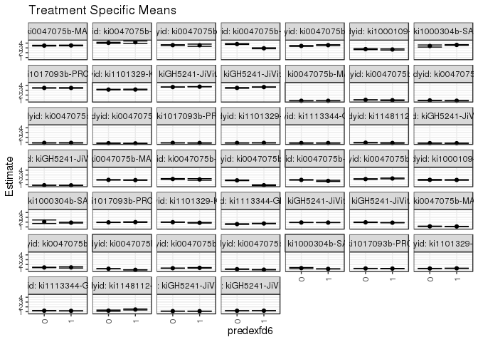

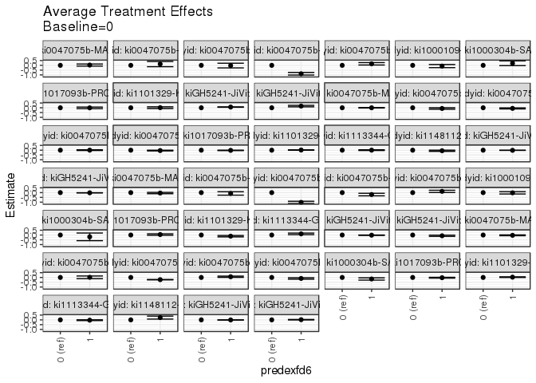

## Results Table

### Parameter: TSM

| agecat | studyid | country | intervention_level | baseline_level | estimate | ci_lower | ci_upper |
| --- | --- | --- | --- | --- | --- | --- | --- |
| 0-3 months | ki0047075b-MAL-ED | BANGLADESH | 0 | NA | 3.4751960 | 3.3981509 | 3.5522410 |
| 0-3 months | ki0047075b-MAL-ED | BANGLADESH | 1 | NA | 3.5061804 | 3.4289068 | 3.5834539 |
| 0-3 months | ki0047075b-MAL-ED | BRAZIL | 0 | NA | 4.0479223 | 3.9363354 | 4.1595093 |
| 0-3 months | ki0047075b-MAL-ED | BRAZIL | 1 | NA | 4.1839197 | 3.9332251 | 4.4346142 |
| 0-3 months | ki0047075b-MAL-ED | INDIA | 0 | NA | 3.5746836 | 3.4935020 | 3.6558653 |
| 0-3 months | ki0047075b-MAL-ED | INDIA | 1 | NA | 3.5518694 | 3.3200521 | 3.7836867 |
| 0-3 months | ki0047075b-MAL-ED | NEPAL | 0 | NA | 3.7990927 | 3.7149241 | 3.8832613 |
| 0-3 months | ki0047075b-MAL-ED | NEPAL | 1 | NA | 2.9202728 | 2.8193458 | 3.0211997 |
| 0-3 months | ki0047075b-MAL-ED | PERU | 0 | NA | 3.4031162 | 3.3192549 | 3.4869774 |
| 0-3 months | ki0047075b-MAL-ED | PERU | 1 | NA | 3.5659126 | 3.4720365 | 3.6597886 |
| 0-3 months | ki1000109-EE | PAKISTAN | 0 | NA | 2.7458633 | 2.6314840 | 2.8602426 |
| 0-3 months | ki1000109-EE | PAKISTAN | 1 | NA | 2.6689783 | 2.5524272 | 2.7855295 |
| 0-3 months | ki1000304b-SAS-CompFeed | INDIA | 0 | NA | 3.3923688 | 3.1740751 | 3.6106624 |
| 0-3 months | ki1000304b-SAS-CompFeed | INDIA | 1 | NA | 3.6134441 | 3.5479026 | 3.6789856 |
| 0-3 months | ki1017093b-PROVIDE | BANGLADESH | 0 | NA | 3.4847708 | 3.4374715 | 3.5320700 |
| 0-3 months | ki1017093b-PROVIDE | BANGLADESH | 1 | NA | 3.4767976 | 3.4087934 | 3.5448018 |
| 0-3 months | ki1101329-Keneba | GAMBIA | 0 | NA | 3.1398091 | 3.0820153 | 3.1976029 |
| 0-3 months | ki1101329-Keneba | GAMBIA | 1 | NA | 3.1503479 | 3.0775369 | 3.2231590 |
| 0-3 months | kiGH5241-JiVitA-3 | BANGLADESH | 0 | NA | 3.6671156 | 3.6498846 | 3.6843466 |
| 0-3 months | kiGH5241-JiVitA-3 | BANGLADESH | 1 | NA | 3.7410748 | 3.7300343 | 3.7521154 |
| 0-3 months | kiGH5241-JiVitA-4 | BANGLADESH | 0 | NA | 3.4868164 | 3.4150952 | 3.5585376 |
| 0-3 months | kiGH5241-JiVitA-4 | BANGLADESH | 1 | NA | 3.6613085 | 3.6285215 | 3.6940954 |
| 3-6 months | ki0047075b-MAL-ED | BANGLADESH | 0 | NA | 1.9815537 | 1.9241637 | 2.0389437 |
| 3-6 months | ki0047075b-MAL-ED | BANGLADESH | 1 | NA | 1.9352217 | 1.8779253 | 1.9925181 |
| 3-6 months | ki0047075b-MAL-ED | BRAZIL | 0 | NA | 2.1618227 | 2.0780342 | 2.2456112 |
| 3-6 months | ki0047075b-MAL-ED | BRAZIL | 1 | NA | 2.0743502 | 1.9051743 | 2.2435262 |
| 3-6 months | ki0047075b-MAL-ED | INDIA | 0 | NA | 1.8818388 | 1.8162399 | 1.9474378 |
| 3-6 months | ki0047075b-MAL-ED | INDIA | 1 | NA | 0.8591314 | 0.7646951 | 0.9535676 |
| 3-6 months | ki0047075b-MAL-ED | NEPAL | 0 | NA | 1.9730098 | 1.9131274 | 2.0328923 |
| 3-6 months | ki0047075b-MAL-ED | NEPAL | 1 | NA | 1.7702821 | 1.6505025 | 1.8900617 |

[output cut: 62 more lines]

### Parameter: E(Y)

| agecat | studyid | country | intervention_level | baseline_level | estimate | ci_lower | ci_upper |
| --- | --- | --- | --- | --- | --- | --- | --- |
| 0-3 months | ki0047075b-MAL-ED | BANGLADESH | NA | NA | 3.5553847 | 3.4920868 | 3.6186827 |
| 0-3 months | ki0047075b-MAL-ED | BRAZIL | NA | NA | 4.0688851 | 3.9665094 | 4.1712608 |
| 0-3 months | ki0047075b-MAL-ED | INDIA | NA | NA | 3.5729366 | 3.4957568 | 3.6501164 |
| 0-3 months | ki0047075b-MAL-ED | NEPAL | NA | NA | 3.8170740 | 3.7403102 | 3.8938378 |
| 0-3 months | ki0047075b-MAL-ED | PERU | NA | NA | 3.3318351 | 3.2689715 | 3.3946986 |
| 0-3 months | ki1000109-EE | PAKISTAN | NA | NA | 2.6575645 | 2.5739973 | 2.7411317 |
| 0-3 months | ki1000304b-SAS-CompFeed | INDIA | NA | NA | 3.6020442 | 3.5415582 | 3.6625301 |
| 0-3 months | ki1017093b-PROVIDE | BANGLADESH | NA | NA | 3.4826706 | 3.4434873 | 3.5218539 |
| 0-3 months | ki1101329-Keneba | GAMBIA | NA | NA | 3.1390821 | 3.0898519 | 3.1883124 |
| 0-3 months | kiGH5241-JiVitA-3 | BANGLADESH | NA | NA | 3.7185042 | 3.7081620 | 3.7288464 |
| 0-3 months | kiGH5241-JiVitA-4 | BANGLADESH | NA | NA | 3.6386843 | 3.6074983 | 3.6698703 |
| 3-6 months | ki0047075b-MAL-ED | BANGLADESH | NA | NA | 1.9343889 | 1.8844588 | 1.9843190 |
| 3-6 months | ki0047075b-MAL-ED | BRAZIL | NA | NA | 2.1478156 | 2.0686357 | 2.2269955 |
| 3-6 months | ki0047075b-MAL-ED | INDIA | NA | NA | 1.8839095 | 1.8218223 | 1.9459968 |
| 3-6 months | ki0047075b-MAL-ED | NEPAL | NA | NA | 1.9673620 | 1.9110737 | 2.0236503 |
| 3-6 months | ki0047075b-MAL-ED | PERU | NA | NA | 2.0207669 | 1.9549762 | 2.0865576 |
| 3-6 months | ki1000109-EE | PAKISTAN | NA | NA | 2.0241201 | 1.9636505 | 2.0845898 |
| 3-6 months | ki1000304b-SAS-CompFeed | INDIA | NA | NA | 1.9051097 | 1.8384221 | 1.9717974 |
| 3-6 months | ki1017093b-PROVIDE | BANGLADESH | NA | NA | 1.9654454 | 1.9303798 | 2.0005110 |
| 3-6 months | ki1101329-Keneba | GAMBIA | NA | NA | 1.9931730 | 1.9526530 | 2.0336930 |
| 3-6 months | ki1113344-GMS-Nepal | NEPAL | NA | NA | 1.7048001 | 1.6654509 | 1.7441494 |
| 3-6 months | kiGH5241-JiVitA-3 | BANGLADESH | NA | NA | 1.9200510 | 1.9095836 | 1.9305183 |
| 3-6 months | kiGH5241-JiVitA-4 | BANGLADESH | NA | NA | 1.8963650 | 1.8662030 | 1.9265270 |
| 6-12 months | ki0047075b-MAL-ED | BANGLADESH | NA | NA | 1.1131603 | 1.0877615 | 1.1385590 |
| 6-12 months | ki0047075b-MAL-ED | BRAZIL | NA | NA | 1.3863464 | 1.3400121 | 1.4326807 |
| 6-12 months | ki0047075b-MAL-ED | INDIA | NA | NA | 1.1214539 | 1.0926522 | 1.1502556 |
| 6-12 months | ki0047075b-MAL-ED | NEPAL | NA | NA | 1.2234287 | 1.1975908 | 1.2492667 |
| 6-12 months | ki0047075b-MAL-ED | PERU | NA | NA | 1.2081188 | 1.1752622 | 1.2409753 |
| 6-12 months | ki1000304b-SAS-CompFeed | INDIA | NA | NA | 1.0940274 | 1.0717512 | 1.1163036 |
| 6-12 months | ki1017093b-PROVIDE | BANGLADESH | NA | NA | 1.1731762 | 1.1558671 | 1.1904853 |
| 6-12 months | ki1101329-Keneba | GAMBIA | NA | NA | 1.1784288 | 1.1595786 | 1.1972791 |
| 6-12 months | ki1113344-GMS-Nepal | NEPAL | NA | NA | 1.1659725 | 1.1463312 | 1.1856138 |
| 6-12 months | ki1148112-LCNI-5 | MALAWI | NA | NA | 1.2437855 | 1.1489803 | 1.3385906 |
| 6-12 months | kiGH5241-JiVitA-3 | BANGLADESH | NA | NA | 1.1067177 | 1.0999609 | 1.1134745 |
| 6-12 months | kiGH5241-JiVitA-4 | BANGLADESH | NA | NA | 1.2020599 | 1.1906612 | 1.2134585 |
| 12-24 months | ki0047075b-MAL-ED | BANGLADESH | NA | NA | 0.8457372 | 0.8296411 | 0.8618334 |
| 12-24 months | ki0047075b-MAL-ED | BRAZIL | NA | NA | 0.9816245 | 0.9508764 | 1.0123725 |
| 12-24 months | ki0047075b-MAL-ED | INDIA | NA | NA | 0.8802656 | 0.8627612 | 0.8977700 |
| 12-24 months | ki0047075b-MAL-ED | NEPAL | NA | NA | 0.8610937 | 0.8457157 | 0.8764716 |
| 12-24 months | ki0047075b-MAL-ED | PERU | NA | NA | 0.8498071 | 0.8294861 | 0.8701282 |
| 12-24 months | ki1017093b-PROVIDE | BANGLADESH | NA | NA | 0.8575519 | 0.8455586 | 0.8695452 |
| 12-24 months | ki1101329-Keneba | GAMBIA | NA | NA | 0.8457043 | 0.8349054 | 0.8565032 |
| 12-24 months | ki1113344-GMS-Nepal | NEPAL | NA | NA | 0.8363408 | 0.8207398 | 0.8519417 |
| 12-24 months | ki1148112-LCNI-5 | MALAWI | NA | NA | 0.8835736 | 0.8376943 | 0.9294529 |
| 12-24 months | kiGH5241-JiVitA-3 | BANGLADESH | NA | NA | 0.7961667 | 0.7908693 | 0.8014641 |
| 12-24 months | kiGH5241-JiVitA-4 | BANGLADESH | NA | NA | 0.8490267 | 0.8432029 | 0.8548505 |

### Parameter: ATE

| agecat | studyid | country | intervention_level | baseline_level | estimate | ci_lower | ci_upper |
| --- | --- | --- | --- | --- | --- | --- | --- |
| 0-3 months | ki0047075b-MAL-ED | BANGLADESH | 0 | 0 | 0.0000000 | 0.0000000 | 0.0000000 |
| 0-3 months | ki0047075b-MAL-ED | BANGLADESH | 1 | 0 | 0.0309844 | -0.0784106 | 0.1403795 |
| 0-3 months | ki0047075b-MAL-ED | BRAZIL | 0 | 0 | 0.0000000 | 0.0000000 | 0.0000000 |
| 0-3 months | ki0047075b-MAL-ED | BRAZIL | 1 | 0 | 0.1359973 | -0.1380965 | 0.4100912 |
| 0-3 months | ki0047075b-MAL-ED | INDIA | 0 | 0 | 0.0000000 | 0.0000000 | 0.0000000 |
| 0-3 months | ki0047075b-MAL-ED | INDIA | 1 | 0 | -0.0228142 | -0.2676714 | 0.2220429 |
| 0-3 months | ki0047075b-MAL-ED | NEPAL | 0 | 0 | 0.0000000 | 0.0000000 | 0.0000000 |
| 0-3 months | ki0047075b-MAL-ED | NEPAL | 1 | 0 | -0.8788200 | -1.0127820 | -0.7448580 |
| 0-3 months | ki0047075b-MAL-ED | PERU | 0 | 0 | 0.0000000 | 0.0000000 | 0.0000000 |
| 0-3 months | ki0047075b-MAL-ED | PERU | 1 | 0 | 0.1627964 | 0.0352828 | 0.2903101 |
| 0-3 months | ki1000109-EE | PAKISTAN | 0 | 0 | 0.0000000 | 0.0000000 | 0.0000000 |
| 0-3 months | ki1000109-EE | PAKISTAN | 1 | 0 | -0.0768850 | -0.2403783 | 0.0866084 |
| 0-3 months | ki1000304b-SAS-CompFeed | INDIA | 0 | 0 | 0.0000000 | 0.0000000 | 0.0000000 |
| 0-3 months | ki1000304b-SAS-CompFeed | INDIA | 1 | 0 | 0.2210753 | -0.0283103 | 0.4704610 |
| 0-3 months | ki1017093b-PROVIDE | BANGLADESH | 0 | 0 | 0.0000000 | 0.0000000 | 0.0000000 |
| 0-3 months | ki1017093b-PROVIDE | BANGLADESH | 1 | 0 | -0.0079732 | -0.0907922 | 0.0748458 |
| 0-3 months | ki1101329-Keneba | GAMBIA | 0 | 0 | 0.0000000 | 0.0000000 | 0.0000000 |
| 0-3 months | ki1101329-Keneba | GAMBIA | 1 | 0 | 0.0105388 | -0.0789659 | 0.1000435 |
| 0-3 months | kiGH5241-JiVitA-3 | BANGLADESH | 0 | 0 | 0.0000000 | 0.0000000 | 0.0000000 |
| 0-3 months | kiGH5241-JiVitA-3 | BANGLADESH | 1 | 0 | 0.0739592 | 0.0552548 | 0.0926637 |
| 0-3 months | kiGH5241-JiVitA-4 | BANGLADESH | 0 | 0 | 0.0000000 | 0.0000000 | 0.0000000 |
| 0-3 months | kiGH5241-JiVitA-4 | BANGLADESH | 1 | 0 | 0.1744921 | 0.0956800 | 0.2533042 |
| 3-6 months | ki0047075b-MAL-ED | BANGLADESH | 0 | 0 | 0.0000000 | 0.0000000 | 0.0000000 |
| 3-6 months | ki0047075b-MAL-ED | BANGLADESH | 1 | 0 | -0.0463320 | -0.1153025 | 0.0226386 |
| 3-6 months | ki0047075b-MAL-ED | BRAZIL | 0 | 0 | 0.0000000 | 0.0000000 | 0.0000000 |
| 3-6 months | ki0047075b-MAL-ED | BRAZIL | 1 | 0 | -0.0874724 | -0.2662161 | 0.0912712 |
| 3-6 months | ki0047075b-MAL-ED | INDIA | 0 | 0 | 0.0000000 | 0.0000000 | 0.0000000 |
| 3-6 months | ki0047075b-MAL-ED | INDIA | 1 | 0 | -1.0227075 | -1.1384598 | -0.9069551 |
| 3-6 months | ki0047075b-MAL-ED | NEPAL | 0 | 0 | 0.0000000 | 0.0000000 | 0.0000000 |
| 3-6 months | ki0047075b-MAL-ED | NEPAL | 1 | 0 | -0.2027278 | -0.3366430 | -0.0688125 |

[output cut: 62 more lines]